# MultiAssayExperiment: Integrative workflow for public multi-omics data

Marcel Ramos

Roswell Park Comprehensive Cancer Center, Buffalo, NY

Ludwig Geistlinger

CUNY School of Public Health, New York, NY

Levi Waldron

CUNY School of Public Health, New York, NY

June 23, 2022

# 1 Multi-omic Integration and Analysis of cBioPortal and TCGA data with MultiAssayExperiment

## 1.1 Workshop participation

- See the instruction [Google slides](https://tinyurl.com/MultiAssayWorkshop)
- Browse to the [workshop website](https://waldronlab.io/MultiAssayWorkshop/). This page includes:
  - [A built version of this workshop](https://waldronlab.io/MultiAssayWorkshop/articles/Ramos_MultiAssayExperiment.html)
  - [List of available cBioPortal studies](https://waldronlab.io/MultiAssayWorkshop/articles/cBioPortal_Studies.html)
  - [TCGA terminology quick-reference](https://waldronlab.io/MultiAssayWorkshop/articles/curatedTCGAData_ref.html)
  - [TCGAutils package cheat-sheet](https://waldronlab.io/MultiAssayWorkshop/articles/TCGAutilsCheatsheet.html)
  - [Build your first MultiAssayExperiment interactive tutorial](https://waldronlab.io/MultiAssayWorkshop/tutorials/Exercise_MultiAssay.html)
  - [Download and use cBioPortal data interactive tutorial](https://waldronlab.io/MultiAssayWorkshop/tutorials/cBioPortalData_Intro.html)
- Run this workshop on the [free Orchestra Cloud platform](http://app.orchestra.cancerdatasci.org/) (search for title: “Multi-omic Integration of cBioPortal and TCGA data with MultiAssayExperiment”)
- Docker users can run this workshop locally via:

```
docker run -e PASSWORD=bioc -p 8787:8787 mr148/multiassayworkshop:latest
```

## 1.2 Requirements: R/Bioconductor packages

The workshop uses a Docker container with Bioconductor devel version `3.14`. If you would like to install Bioconductor on your computer **at a later date**, see the [Bioconductor installation](https://www.bioconductor.org/install) instructions.

Here is a list of packages that we will be using:

```r
library(MultiAssayExperiment)
library(curatedTCGAData)
library(cBioPortalData)
library(TCGAutils)
library(SingleCellMultiModal)
library(UpSetR)
library(GenomicDataCommons)
```

### 1.2.1 Citing MultiAssayExperiment

Please use these citations (Ramos et al. 2017) and (Ramos et al. 2020) when using `MultiAssayExperiment`, `curatedTCGAData`, or `cBioPortalData`. Your citations are very much appreciated!

### 1.2.2 Overview of Packages

| Package | Description |
| --- | --- |
| MultiAssayExperiment | Infrastructure package to represent multi-omics data |
| curatedTCGAData | Downloads TCGA data from ExperimentHub in MultiAssayExperiment form |
| cBioPortalData | Access over 300 study datasets from the cBio Genomics Portal |
| TCGAutils | Make use of utility functions for working with TCGA data |
| SingleCellMultiModal | Obtain single cell data from various multi-modality studies |

### 1.2.3 Key Packages

#### 1.2.3.1 `MultiAssayExperiment`

- provides an integrative representation for multi-omics data
- modelled after the `SummarizedExperiment` representation for expression data
- easy-to-use operations for manipulating multiple sets of data such as copy number alterations, mutations, proteomics, methylation, and more

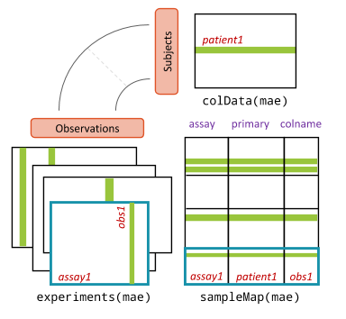

MultiAssayExperiment object schematic

#### 1.2.3.2 `cBioPortalData`

- R/Bioconductor interface to cBioPortal data
- makes use of the revamped API with caching
- queries are handled for the user *in the background*
- easy-to-use interface (no knowledge of the cBioPortal data model required)
- see `getStudies()` for a list of available studies

#### 1.2.3.3 `curatedTCGAData`

- Many tools exist for accessing and downloading [The Cancer Genome Atlas](https://www.cancer.gov/about-nci/organization/ccg/research/structural-genomics/tcga) data: `RTCGAToolbox`, `GenomicDataCommons`, `TCGAbiolinks`, `cBioPortal` website, Broad GDAC Firehose, and more
- makes it easy to obtain user-friendly and integrative data at very little cognitive overhead
- conveniently places data in the analysis platform of choice, R/Bioconductor
- provides 33 different cancer types from the [Broad GDAC Firehose](https://gdac.broadinstitute.org)
  - On-the-fly construction from ‘flat’ files
  - `hg19` data
  - `MultiAssayExperiment` representations

Reference vignettes:

- `Available Studies` – (curatedTCGAData section) A list of available cancer studies from `TCGAutils::diseaseCodes`.
- `OmicsTypes` – A descriptive table of ’omics types in `curatedTCGAData` (thanks to Ludwig G. `@lgeistlinger`)

#### 1.2.3.4 `SingleCellMultiModal`

- Serves multi-modal datasets from GEO and other sources as `MultiAssayExperiment` data representations. Some representations are out of memory using the `HDF5` format as well as the `MTX` format.
- Available technologies are scNMT, 10X Multiome, seqFISH, (EC)CITEseq, SCoPE2 and others.

#### 1.2.3.5 `TCGAutils`

- allows additional exploration, and manipulation of samples and metadata
- User-friendly operations for subsetting, separating, converting, and reshaping of sample and feature TCGA data
- developed specifically for TCGA data and `curatedTCGAData` outputs

It provides convenience / helper functions in three major areas:

1. conversion / summarization of row annotations to genomic ranges
2. identification and separation of samples
3. translation and interpretation of TCGA identifiers

For the cheatsheet reference table, see the TCGAutils Cheatsheet.

To better understand how it all fits together, this schematic shows the relationship among all as part of the curatedTCGAData pipeline.

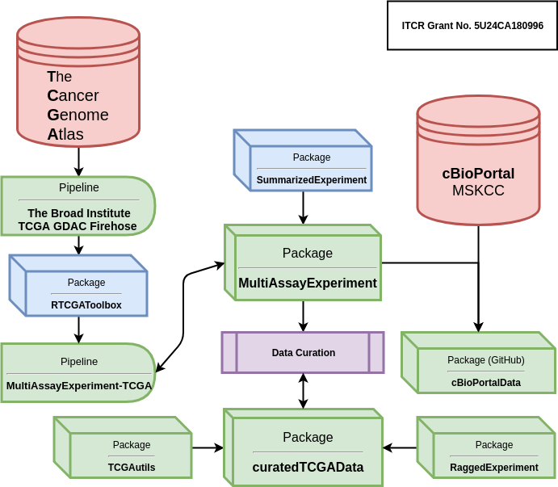

Schematic of curatedTCGAData Pipeline

### 1.2.4 Data Classes

This section summarizes three fundamental data classes for the representation of multi-omics experiments.

#### 1.2.4.1 `(Ranged)SummarizedExperiment`

A matrix-like container where rows represent features of interest and columns represent samples. The objects contain one or more assays, each represented by a matrix-like object of numeric or other mode.

- matrix-like representation of experimental data including RNA sequencing and microarray experiments.
- stores multiple experimental data matrices of identical dimensions, with associated metadata on:
  - the rows/genes/transcripts/other measurements (`rowData`)
  - column/sample phenotype or clinical data (`colData`)
  - overall experiment (`metadata`).
- `RangedSummarizedExperiment` associates a `GRanges` or `GRangesList` vector with the rows

*Note*. Many other classes for experimental data are actually derived from `SummarizedExperiment` (e.g., `SingleCellExperiment` for single-cell RNA sequencing experiments)

```r
library(SingleCellExperiment)
extends("SingleCellExperiment")
```

```
## [1] "SingleCellExperiment"       "RangedSummarizedExperiment"
## [3] "SummarizedExperiment"       "RectangularData"
## [5] "Vector"                     "Annotated"
## [7] "vector_OR_Vector"
```

#### 1.2.4.2 `RaggedExperiment`

- flexible representation for segmented copy number, somatic mutations such as represented in `.vcf` files, and other ragged array schema for genomic location data.
- similar to the `GRangesList` class in `GenomicRanges`
- used to represent *differing* genomic ranges on each of a set of samples

```r
showClass("RaggedExperiment")
```

```
## Class "RaggedExperiment" [package "RaggedExperiment"]
##
## Slots:
##
## Name:       assays      rowidx      colidx    metadata
## Class: GRangesList     integer     integer        list
##
## Extends: "Annotated"
```

`RaggedExperiment` provides a flexible set of _*Assay_ methods to support transformation of ranged list data to matrix format.

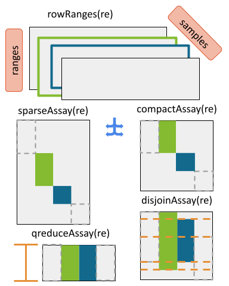

## 1.3 The Integrative Container

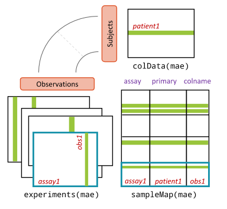

`MultiAssayExperiment` object schematic. colData provides data about the patients, cell lines, or other biological units, with one row per unit and one column per variable. The experiments are a list of assay datasets of arbitrary class. The sampleMap relates each column (observation) in ExperimentList to exactly one row (biological unit) in colData; however, one row of colData may map to zero, one, or more columns per assay, allowing for missing and replicate assays. sampleMap allows for per-assay sample naming conventions. Metadata can be used to store information in arbitrary format about the MultiAssayExperiment. Green stripes indicate a mapping of one subject to multiple observations across experiments.

### 1.3.1 `MultiAssayExperiment`

- coordinates multi-omics experiment data on a set of biological specimens
- can contain any number of assays with different representations and *dimensions*
- assays can be *ID-based*, where measurements are indexed identifiers of genes, microRNA, proteins, microbes, etc.
- assays may be *range-based*, where measurements correspond to genomic ranges that can be represented as `GRanges` objects, such as gene expression or copy number.

**Click** on the fold to see what data classes are supported!**

1. `matrix`: the most basic class for ID-based datasets, could be used for example for gene expression summarized per-gene, microRNA, metabolomics, or microbiome data.
2. `SummarizedExperiment` and derived methods: described above, could be used for miRNA, gene expression, proteomics, or any matrix-like data where measurements are represented by IDs.
3. `RangedSummarizedExperiment`: described above, could be used for gene expression, methylation, or other data types referring to genomic positions.
4. `ExpressionSet`: Another rich representation for ID-based datasets, supported only for legacy reasons
5. `RaggedExperiment`: described above, for non-rectangular (ragged) ranged-based datasets such as segmented copy number, where segmentation of copy number alterations occurs and different genomic locations in each sample.
6. `RangedVcfStack`: For VCF archives broken up by chromosome (see `VcfStack` class defined in the `GenomicFiles` package)
7. `DelayedMatrix`: An on-disk representation of matrix-like objects for large datasets. It reduces memory usage and optimizes performance with delayed operations. This class is part of the `DelayedArray` package.

*Note*. Data classes that support row and column naming and subsetting may be used in a `MultiAssayExperiment`.

### 1.3.2 `MatchedAssayExperiment`

- uniform subclass of `MultiAssayExperiment`
- “all patients have a sample in each assay”

```r
# coercion
as(x, "MatchedAssayExperiment")

# construction from MAE
MatchedAssayExperiment(mae)
```

*Note*. The `MultiAssayExperiment` package provides functionality to merge replicate profiles for a single patient (`mergeReplicates()`).

**Key points**

- `MultiAssayExperiment` coordinates different Bioconductor classes into one unified object
- `MultiAssayExperiment` is an infrastructure package while `curatedTCGAData` and `cBioPortalData` provide data on cancer studies including TCGA

## 1.4 Building from Scratch: `MultiAssayExperiment`

### 1.4.1 `miniACC` Demo

Get started by trying out `MultiAssayExperiment` using a subset of the TCGA adrenocortical carcinoma (ACC) dataset provided with the package. This dataset provides five assays on 92 patients, although all five assays were not performed for every patient:

1. **RNASeq2GeneNorm**: gene mRNA abundance by RNA-seq
2. **gistict**: GISTIC genomic copy number by gene
3. **RPPAArray**: protein abundance by Reverse Phase Protein Array
4. **Mutations**: non-silent somatic mutations by gene
5. **miRNASeqGene**: microRNA abundance by microRNA-seq.

```r
data("miniACC")
miniACC
```

```
## A MultiAssayExperiment object of 5 listed
##  experiments with user-defined names and respective classes.
##  Containing an ExperimentList class object of length 5:
##  [1] RNASeq2GeneNorm: SummarizedExperiment with 198 rows and 79 columns
##  [2] gistict: SummarizedExperiment with 198 rows and 90 columns
##  [3] RPPAArray: SummarizedExperiment with 33 rows and 46 columns
##  [4] Mutations: matrix with 97 rows and 90 columns
##  [5] miRNASeqGene: SummarizedExperiment with 471 rows and 80 columns
## Functionality:
##  experiments() - obtain the ExperimentList instance
##  colData() - the primary/phenotype DataFrame
##  sampleMap() - the sample coordination DataFrame
##  `$`, `[`, `[[` - extract colData columns, subset, or experiment
##  *Format() - convert into a long or wide DataFrame
##  assays() - convert ExperimentList to a SimpleList of matrices
##  exportClass() - save data to flat files
```

### 1.4.2 `shiny` Demo

Click Here to open the `shiny` tutorial.

**Key points**

- Extractor functions allow users to take components from the `MultiAssayExperiment` object
- They’re usually the same name as the component except for `experiments` which extracts the `ExperimentList`

## 1.5 Notes on Working with MultiAssayExperiment

### 1.5.1 API cheat sheet

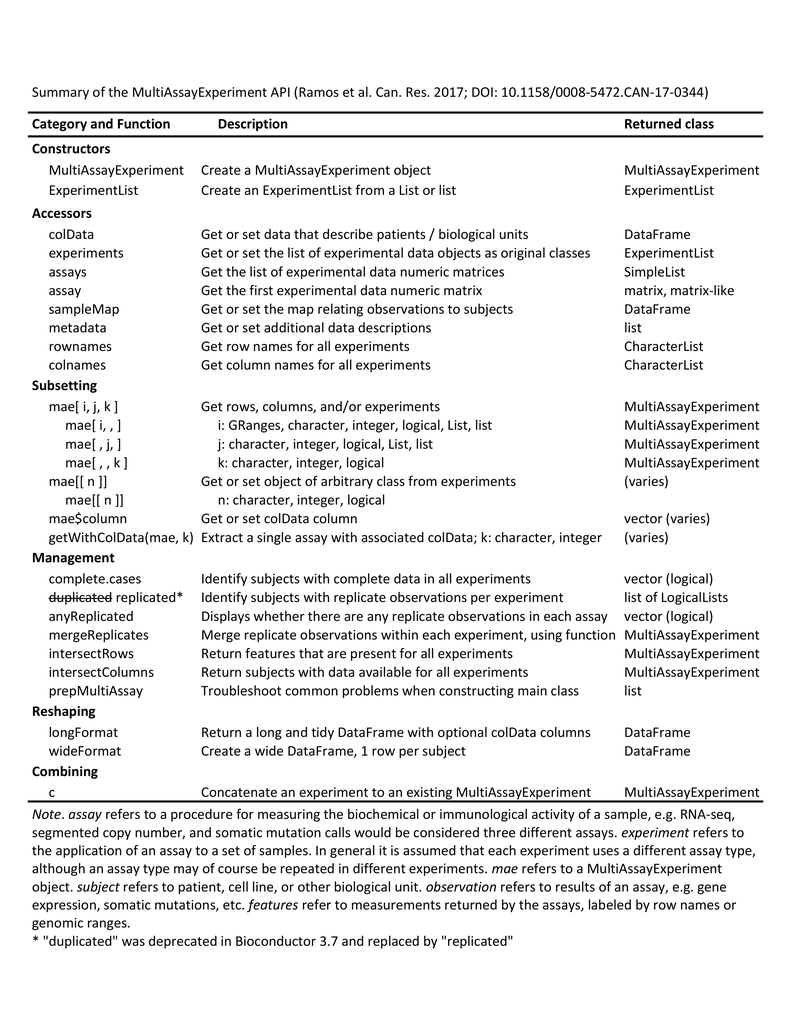

The MultiAssayExperiment API for construction, access, subsetting, management, and reshaping to formats for application of R/Bioconductor graphics and analysis packages.

### 1.5.2 MultiAssayExperiment construction and concatenation

#### 1.5.2.1 constructor function

The `MultiAssayExperiment` constructor function accepts three arguments:

1. `experiments` - An `ExperimentList` or `list` of rectangular data
2. `colData` - A `DataFrame` describing the patients (or cell lines, or other biological units)
3. `sampleMap` - A `DataFrame` of `assay`, `primary`, and `colname` identifiers

The miniACC object can be reconstructed as follows:

```r
MultiAssayExperiment(
    experiments = experiments(miniACC),
    colData = colData(miniACC),
    sampleMap = sampleMap(miniACC),
    metadata = metadata(miniACC)
)
```

```
## A MultiAssayExperiment object of 5 listed
##  experiments with user-defined names and respective classes.
##  Containing an ExperimentList class object of length 5:
##  [1] RNASeq2GeneNorm: SummarizedExperiment with 198 rows and 79 columns
##  [2] gistict: SummarizedExperiment with 198 rows and 90 columns
##  [3] RPPAArray: SummarizedExperiment with 33 rows and 46 columns
##  [4] Mutations: matrix with 97 rows and 90 columns
##  [5] miRNASeqGene: SummarizedExperiment with 471 rows and 80 columns
## Functionality:
##  experiments() - obtain the ExperimentList instance
##  colData() - the primary/phenotype DataFrame
##  sampleMap() - the sample coordination DataFrame
##  `$`, `[`, `[[` - extract colData columns, subset, or experiment
##  *Format() - convert into a long or wide DataFrame
##  assays() - convert ExperimentList to a SimpleList of matrices
##  exportClass() - save data to flat files
```

#### 1.5.2.2 Getting help with `prepMultiAssay`

The `prepMultiAssay` function allows the user to diagnose typical problems when creating a `MultiAssayExperiment` object. See `?prepMultiAssay` for more details.

#### 1.5.2.3 Combining MultiAssayExperiment object with the `c` function

The `c` function allows the user to concatenate an additional experiment to an existing `MultiAssayExperiment`. The optional `sampleMap` argument allows concatenating an assay whose column names do not match the row names of `colData`. For convenience, the *mapFrom* argument allows the user to map from a particular experiment **provided** that the **order** of the colnames is in the **same**. A `warning` will be issued to make the user aware of this assumption. For example, to concatenate a matrix of log2-transformed RNA-seq results:

```r
miniACC2 <- c(
    miniACC,
    log2rnaseq = log2(assays(miniACC)$RNASeq2GeneNorm),
    mapFrom=1L
)
```

```
## Warning: Assuming column order in the data provided
##  matches the order in 'mapFrom' experiment(s) colnames
```

```r
experiments(miniACC2)
```

```
## ExperimentList class object of length 6:
##  [1] RNASeq2GeneNorm: SummarizedExperiment with 198 rows and 79 columns
##  [2] gistict: SummarizedExperiment with 198 rows and 90 columns
##  [3] RPPAArray: SummarizedExperiment with 33 rows and 46 columns
##  [4] Mutations: matrix with 97 rows and 90 columns
##  [5] miRNASeqGene: SummarizedExperiment with 471 rows and 80 columns
##  [6] log2rnaseq: matrix with 198 rows and 79 columns
```

### 1.5.3 colData - information biological units

This slot is a `DataFrame` describing the characteristics of biological units, for example clinical data for patients. In the prepared datasets from [The Cancer Genome Atlas](https://www.cancer.gov/about-nci/organization/ccg/research/structural-genomics/tcga), each row is one patient and each column is a clinical, pathological, subtype, or other variable. The `$` function provides a shortcut for accessing or setting `colData` columns.

```r
colData(miniACC)[1:4, 1:4]
```

```
## DataFrame with 4 rows and 4 columns
##                 patientID years_to_birth vital_status days_to_death
##               <character>      <integer>    <integer>     <integer>
## TCGA-OR-A5J1 TCGA-OR-A5J1             58            1          1355
## TCGA-OR-A5J2 TCGA-OR-A5J2             44            1          1677
## TCGA-OR-A5J3 TCGA-OR-A5J3             23            0            NA
## TCGA-OR-A5J4 TCGA-OR-A5J4             23            1           423
```

```r
table(miniACC$race)
```

```
##
##                     asian black or african american                     white
##                         2                         1                        78
```

Note. `MultiAssayExperiment` supports both missing observations and replicate observations, i.e., one row of `colData` can map to 0, 1, or more columns of any of the experimental data matrices. One could therefore treat replicate observations as one or multiple rows of `colData`. This can result in different subsetting, `duplicated()`, and `wideFormat()` behaviors.

Note. Multiple time points, or distinct biological replicates, can be separate rows of the `colData`.

**Key points**

- Each row maps to zero or more observations in each experiment
- Usually, organized as one row per biological unit

### 1.5.4 ExperimentList - experiment data

Experimental datasets can be input as either a base `list` or `ExperimentList` object for the set of samples collected. To see the experiments use the `experiments` getter function.

```r
experiments(miniACC)
```

```
## ExperimentList class object of length 5:
##  [1] RNASeq2GeneNorm: SummarizedExperiment with 198 rows and 79 columns
##  [2] gistict: SummarizedExperiment with 198 rows and 90 columns
##  [3] RPPAArray: SummarizedExperiment with 33 rows and 46 columns
##  [4] Mutations: matrix with 97 rows and 90 columns
##  [5] miRNASeqGene: SummarizedExperiment with 471 rows and 80 columns
```

Note. Each matrix column must correspond to exactly one row in `colData`. In other words, each patient or cell line must be traceable. However, multiple columns can come from the same patient, or there can be no data for that patient.

*Key points:*

- One rectangular dataset per list element
- One column per assayed specimen.
- Matrix rows correspond to variables, e.g. genes or genomic ranges
- `ExperimentList` elements can be genomic range-based (e.g. `SummarizedExperiment` or `RaggedExperiment`) or ID-based data
- Most rectangular-type data classes are supported

Note. Any data class can be included in the `ExperimentList`, as long as it supports: single-bracket subsetting (`[`), `dimnames`, and `dim`. Most data classes defined in Bioconductor meet these requirements.

### 1.5.5 sampleMap - relationship graph

`sampleMap` is a graph representation of the relationship between biological units and experimental results. In simple cases where the column names of `ExperimentList` data matrices match the row names of `colData`, the user won’t need to specify or think about a sample map, it can be created automatically by the `MultiAssayExperiment` constructor. `sampleMap` is a simple three-column `DataFrame`:

1. `assay` column: the name of the assay, and found in the names of `ExperimentList` list names
2. `primary` column: identifiers of patients or biological units, and found in the row names of `colData`
3. `colname` column: identifiers of assay results, and found in the column names of `ExperimentList` elements Helper functions are available for creating a map from a list. See `?listToMap`

```r
sampleMap(miniACC)
```

```
## DataFrame with 385 rows and 3 columns
##               assay      primary                colname
##            <factor>  <character>            <character>
## 1   RNASeq2GeneNorm TCGA-OR-A5J1 TCGA-OR-A5J1-01A-11R..
## 2   RNASeq2GeneNorm TCGA-OR-A5J2 TCGA-OR-A5J2-01A-11R..
## 3   RNASeq2GeneNorm TCGA-OR-A5J3 TCGA-OR-A5J3-01A-11R..
## 4   RNASeq2GeneNorm TCGA-OR-A5J5 TCGA-OR-A5J5-01A-11R..
## 5   RNASeq2GeneNorm TCGA-OR-A5J6 TCGA-OR-A5J6-01A-31R..
## ...             ...          ...                    ...
## 381    miRNASeqGene TCGA-PA-A5YG TCGA-PA-A5YG-01A-11R..
## 382    miRNASeqGene TCGA-PK-A5H8 TCGA-PK-A5H8-01A-11R..
## 383    miRNASeqGene TCGA-PK-A5H9 TCGA-PK-A5H9-01A-11R..
## 384    miRNASeqGene TCGA-PK-A5HA TCGA-PK-A5HA-01A-11R..
## 385    miRNASeqGene TCGA-PK-A5HB TCGA-PK-A5HB-01A-11R..
```

*Key points:*

- relates experimental observations (`colnames`) to `colData`
- permits experiment-specific sample naming, missing, and replicate observations

back to top

### 1.5.6 metadata

Metadata can be used to keep additional information about patients, assays performed on individuals or on the entire cohort, or features such as genes, proteins, and genomic ranges. There are many options available for storing metadata. First, `MultiAssayExperiment` has its own metadata for describing the entire experiment:

```r
metadata(miniACC)
```

```
## $title
## [1] "Comprehensive Pan-Genomic Characterization of Adrenocortical Carcinoma"
##
## $PMID
## [1] "27165744"
##
## $sourceURL
## [1] "http://s3.amazonaws.com/multiassayexperiments/accMAEO.rds"
##
## $RPPAfeatureDataURL
## [1] "http://genomeportal.stanford.edu/pan-tcga/show_target_selection_file?filename=Allprotein.txt"
##
## $colDataExtrasURL
## [1] "http://www.cell.com/cms/attachment/2062093088/2063584534/mmc3.xlsx"
```

Additionally, the `DataFrame` class used by `sampleMap` and `colData`, as well as the `ExperimentList` class, similarly support metadata. Finally, many experimental data objects that can be used in the `ExperimentList` support metadata. These provide flexible options to users and to developers of derived classes.

## 1.6 The Cancer Genome Atlas (TCGA) Data from `curatedTCGAData`

Most unrestricted TCGA data (from 33 cancer types) are available as `MultiAssayExperiment` objects from the `curatedTCGAData` package. This represents a lot of harmonization!

Here we list the available data for the Adrenocortical Carcinoma (`"ACC"`) cancer type:

```r
library(curatedTCGAData)
curatedTCGAData("ACC", version = "2.0.1", dry.run = TRUE)
```

[output not shown]

We then download the data with `dry.run` set to `FALSE`.

```r
acc <- curatedTCGAData(
    diseaseCode = "ACC",
    assays = c(
        "miRNASeqGene", "RPPAArray", "Mutation", "RNASeq2GeneNorm", "CNVSNP"
    ),
    version = "2.0.1",
    dry.run = FALSE
)
acc
```

```
## A MultiAssayExperiment object of 5 listed
##  experiments with user-defined names and respective classes.
##  Containing an ExperimentList class object of length 5:
##  [1] ACC_CNVSNP-20160128: RaggedExperiment with 21052 rows and 180 columns
##  [2] ACC_miRNASeqGene-20160128: SummarizedExperiment with 1046 rows and 80 columns
##  [3] ACC_Mutation-20160128: RaggedExperiment with 20166 rows and 90 columns
##  [4] ACC_RNASeq2GeneNorm-20160128: SummarizedExperiment with 20501 rows and 79 columns
##  [5] ACC_RPPAArray-20160128: SummarizedExperiment with 192 rows and 46 columns
## Functionality:
##  experiments() - obtain the ExperimentList instance
##  colData() - the primary/phenotype DataFrame
##  sampleMap() - the sample coordination DataFrame
##  `$`, `[`, `[[` - extract colData columns, subset, or experiment
##  *Format() - convert into a long or wide DataFrame
##  assays() - convert ExperimentList to a SimpleList of matrices
##  exportClass() - save data to flat files
```

These objects contain most unrestricted TCGA assay and clinical / pathological data, as well as some curated data from the supplements of published TCGA primary papers at the end of the colData columns:

```r
dim(colData(acc))
```

```
## [1]  92 822
```

```r
tail(colnames(colData(acc)), 10)
```

```
##  [1] "MethyLevel"       "miRNA.cluster"    "SCNA.cluster"     "protein.cluster"
##  [5] "COC"              "OncoSign"         "purity"           "ploidy"
##  [9] "genome_doublings" "ADS"
```

## 1.7 `cBioPortalData`

To date, the [cBio Genomics Portal](https://www.cbioportal.org/) provides access to more than 300 datasets collected and curated from different instutions.

There are two main ways of accessing this data:

1. `cBioDataPack` - tarball (`.tar.gz`) data files
2. `cBioPortalData` - data from the API

*Note*. `pkgdown` reference website here: https://waldronlab.io/cBioPortalData/

### 1.7.1 Listing the studies available

First, we create an API object using the `cBioPortal` function. This will allow us to subsequently generate queries for the service.

```r
cbio <- cBioPortal()
getStudies(cbio)
```

```
## # A tibble: 347 × 13
##    name          description publicStudy groups status importDate allSampleCount
##    <chr>         <chr>       <lgl>       <chr>   <int> <chr>               <int>
##  1 Adrenocortic… "TCGA Adre… TRUE        "PUBL…      0 2022-03-0…             92
##  2 Bladder Canc… "Whole exo… TRUE        ""          0 2022-03-0…             34
##  3 Basal Cell C… "Whole-exo… TRUE        "PUBL…      0 2022-03-0…            293
##  4 Acute Lympho… "Comprehen… TRUE        "PUBL…      0 2022-03-0…             93
##  5 Ampullary Ca… "Exome seq… TRUE        "PUBL…      0 2022-03-0…            160
##  6 Bladder Urot… "Whole exo… TRUE        "PUBL…      0 2022-03-0…             50
##  7 Bladder Canc… "Comprehen… TRUE        "PUBL…      0 2022-03-0…             97
##  8 Bladder Urot… "Whole-exo… TRUE        "PUBL…      0 2022-03-0…             99
##  9 Bladder Canc… "Genomic P… TRUE        "PUBL…      0 2022-03-0…            109
## 10 Hypodiploid … "Whole gen… TRUE        ""          0 2022-03-0…             44
## # … with 337 more rows, and 6 more variables: readPermission <lgl>,
## #   studyId <chr>, cancerTypeId <chr>, referenceGenome <chr>, pmid <chr>,
## #   citation <chr>
```

We can also see the build status of the datasets using the `buildReport` argument.

```r
getStudies(cbio, buildReport = TRUE)
```

```
## # A tibble: 347 × 15
##    name          description publicStudy groups status importDate allSampleCount
##    <chr>         <chr>       <lgl>       <chr>   <int> <chr>               <int>
##  1 Adrenocortic… "TCGA Adre… TRUE        "PUBL…      0 2022-03-0…             92
##  2 Bladder Canc… "Whole exo… TRUE        ""          0 2022-03-0…             34
##  3 Basal Cell C… "Whole-exo… TRUE        "PUBL…      0 2022-03-0…            293
##  4 Acute Lympho… "Comprehen… TRUE        "PUBL…      0 2022-03-0…             93
##  5 Ampullary Ca… "Exome seq… TRUE        "PUBL…      0 2022-03-0…            160
##  6 Bladder Urot… "Whole exo… TRUE        "PUBL…      0 2022-03-0…             50
##  7 Bladder Canc… "Comprehen… TRUE        "PUBL…      0 2022-03-0…             97
##  8 Bladder Urot… "Whole-exo… TRUE        "PUBL…      0 2022-03-0…             99
##  9 Bladder Canc… "Genomic P… TRUE        "PUBL…      0 2022-03-0…            109
## 10 Hypodiploid … "Whole gen… TRUE        ""          0 2022-03-0…             44
## # … with 337 more rows, and 8 more variables: readPermission <lgl>,
## #   studyId <chr>, cancerTypeId <chr>, referenceGenome <chr>, pmid <chr>,
## #   citation <chr>, api_build <lgl>, pack_build <lgl>
```

This adds two additional columns to the end of the dataset reporting the status of the builds. Not all studies can be converted to `MultiAssayExperiment`. Some studies require additonal cleaning to be represented with `MultiAssayExperiment`.

### 1.7.2 cBioDataPack

```r
library(cBioPortalData)

(uvm <- cBioDataPack("uvm_tcga"))
```

```
## A MultiAssayExperiment object of 9 listed
##  experiments with user-defined names and respective classes.
##  Containing an ExperimentList class object of length 9:
##  [1] cna_hg19.seg: RaggedExperiment with 7618 rows and 80 columns
##  [2] CNA: SummarizedExperiment with 24776 rows and 80 columns
##  [3] linear_CNA: SummarizedExperiment with 24776 rows and 80 columns
##  [4] methylation_hm450: SummarizedExperiment with 15469 rows and 80 columns
##  [5] mutations_extended: RaggedExperiment with 2174 rows and 80 columns
##  [6] mutations_mskcc: RaggedExperiment with 2174 rows and 80 columns
##  [7] RNA_Seq_v2_expression_median: SummarizedExperiment with 20531 rows and 80 columns
##  [8] RNA_Seq_v2_mRNA_median_all_sample_Zscores: SummarizedExperiment with 20531 rows and 80 columns
##  [9] RNA_Seq_v2_mRNA_median_Zscores: SummarizedExperiment with 20440 rows and 80 columns
## Functionality:
##  experiments() - obtain the ExperimentList instance
##  colData() - the primary/phenotype DataFrame
##  sampleMap() - the sample coordination DataFrame
##  `$`, `[`, `[[` - extract colData columns, subset, or experiment
##  *Format() - convert into a long or wide DataFrame
##  assays() - convert ExperimentList to a SimpleList of matrices
##  exportClass() - save data to flat files
```

### 1.7.3 cBioPortalData

```r
(
    urcc <- cBioPortalData(
        cbio, studyId = "urcc_mskcc_2016", genePanelId = "IMPACT341"
    )
)
```

```
## A MultiAssayExperiment object of 2 listed
##  experiments with user-defined names and respective classes.
##  Containing an ExperimentList class object of length 2:
##  [1] urcc_mskcc_2016_cna: SummarizedExperiment with 214 rows and 62 columns
##  [2] urcc_mskcc_2016_mutations: RangedSummarizedExperiment with 147 rows and 53 columns
## Functionality:
##  experiments() - obtain the ExperimentList instance
##  colData() - the primary/phenotype DataFrame
##  sampleMap() - the sample coordination DataFrame
##  `$`, `[`, `[[` - extract colData columns, subset, or experiment
##  *Format() - convert into a long or wide DataFrame
##  assays() - convert ExperimentList to a SimpleList of matrices
##  exportClass() - save data to flat files
```

**Key points**

- `curatedTCGAData` provides TCGA data with some curation including tumor subtype information
- `cBioPortalData` has two main functions, one for downloading pre-packaged data and another for sending queries through the cBioPortal API

## 1.8 Utilities for TCGA

Aside from the available reshaping functions already included in the `MultiAssayExperiment` package, the `TCGAutils` package provides additional helper functions for working with TCGA data.

A number of helper functions are available for managing datasets from `curatedTCGAData`. These include:

- Conversions of `SummarizedExperiment` to `RangedSummarizedExperiment` based on `TxDb.Hsapiens.UCSC.hg19.knownGene` for:
  - `mirToRanges()`: microRNA
  - `symbolsToRanges()`: gene symbols
  - `qreduceTCGA()`: convert `RaggedExperiment` objects to `RangedSummarizedExperiment` with one row per gene symbol, for:
    - segmented copy number datasets (“CNVSNP” and “CNASNP”)
    - somatic mutation datasets (“Mutation”), with a value of 1 for any non-silent mutation and a value of 0 for no mutation or silent mutation

### 1.8.1 (1) Conversion of row metadata for `curatedTCGAData` objects

#### 1.8.1.1 `mirToRanges`

microRNA assays obtained from `curatedTCGAData` have annotated sequences that can be converted to genomic ranges using the `mirbase.db` package. The function looks up all sequences and converts them to (‘hg19’) ranges. For those rows that cannot be found, an ‘unranged’ assay is introduced in the resulting MultiAssayExperiment object.

```r
mirToRanges(acc)
```

```
## harmonizing input:
##   removing 80 sampleMap rows not in names(experiments)
```

```
## A MultiAssayExperiment object of 6 listed
##  experiments with user-defined names and respective classes.
##  Containing an ExperimentList class object of length 6:
##  [1] ACC_CNVSNP-20160128: RaggedExperiment with 21052 rows and 180 columns
##  [2] ACC_Mutation-20160128: RaggedExperiment with 20166 rows and 90 columns
##  [3] ACC_RNASeq2GeneNorm-20160128: SummarizedExperiment with 20501 rows and 79 columns
##  [4] ACC_RPPAArray-20160128: SummarizedExperiment with 192 rows and 46 columns
##  [5] ACC_miRNASeqGene-20160128_ranged: RangedSummarizedExperiment with 1002 rows and 80 columns
##  [6] ACC_miRNASeqGene-20160128_unranged: SummarizedExperiment with 44 rows and 80 columns
## Functionality:
##  experiments() - obtain the ExperimentList instance
##  colData() - the primary/phenotype DataFrame
##  sampleMap() - the sample coordination DataFrame
##  `$`, `[`, `[[` - extract colData columns, subset, or experiment
##  *Format() - convert into a long or wide DataFrame
##  assays() - convert ExperimentList to a SimpleList of matrices
##  exportClass() - save data to flat files
```

#### 1.8.1.2 `qreduceTCGA`

The `qreduceTCGA` function converts `RaggedExperiment` mutation data objects to `RangedSummarizedExperiment` using `org.Hs.eg.db` and the `qreduceTCGA` utility function from `RaggedExperiment` to summarize ‘silent’ and ‘non-silent’ mutations based on a ‘Variant_Classification’ metadata column in the original object.

```r
## Update build metadata to "hg19"
genome(acc[["ACC_Mutation-20160128"]]) <- "NCBI37"
seqlevelsStyle(acc[["ACC_Mutation-20160128"]]) <- "UCSC"

gnome <- genome(acc[["ACC_Mutation-20160128"]])
gnome <- translateBuild(gnome)
genome(acc[["ACC_Mutation-20160128"]]) <- gnome

qreduceTCGA(acc)
```

```
##   403 genes were dropped because they have exons located on both strands
##   of the same reference sequence or on more than one reference sequence,
##   so cannot be represented by a single genomic range.
##   Use 'single.strand.genes.only=FALSE' to get all the genes in a
##   GRangesList object, or use suppressMessages() to suppress this message.
```

```
## harmonizing input:
##   removing 270 sampleMap rows not in names(experiments)
```

```
## A MultiAssayExperiment object of 5 listed
##  experiments with user-defined names and respective classes.
##  Containing an ExperimentList class object of length 5:
##  [1] ACC_miRNASeqGene-20160128: SummarizedExperiment with 1046 rows and 80 columns
##  [2] ACC_RNASeq2GeneNorm-20160128: SummarizedExperiment with 20501 rows and 79 columns
##  [3] ACC_RPPAArray-20160128: SummarizedExperiment with 192 rows and 46 columns
##  [4] ACC_Mutation-20160128_simplified: RangedSummarizedExperiment with 22911 rows and 90 columns
##  [5] ACC_CNVSNP-20160128_simplified: RangedSummarizedExperiment with 22911 rows and 180 columns
## Functionality:
##  experiments() - obtain the ExperimentList instance
##  colData() - the primary/phenotype DataFrame
##  sampleMap() - the sample coordination DataFrame
##  `$`, `[`, `[[` - extract colData columns, subset, or experiment
##  *Format() - convert into a long or wide DataFrame
##  assays() - convert ExperimentList to a SimpleList of matrices
##  exportClass() - save data to flat files
```

#### 1.8.1.3 `symbolsToRanges`

In the cases where row annotations indicate gene symbols, the `symbolsToRanges` utility function converts genes to genomic ranges and replaces existing assays with `RangedSummarizedExperiment` objects. Gene annotations are given as ‘hg19’ genomic regions.

```r
symbolsToRanges(acc)
```

```
##   403 genes were dropped because they have exons located on both strands
##   of the same reference sequence or on more than one reference sequence,
##   so cannot be represented by a single genomic range.
##   Use 'single.strand.genes.only=FALSE' to get all the genes in a
##   GRangesList object, or use suppressMessages() to suppress this message.
```

```
## harmonizing input:
##   removing 79 sampleMap rows not in names(experiments)
```

```
## A MultiAssayExperiment object of 6 listed
##  experiments with user-defined names and respective classes.
##  Containing an ExperimentList class object of length 6:
##  [1] ACC_CNVSNP-20160128: RaggedExperiment with 21052 rows and 180 columns
##  [2] ACC_miRNASeqGene-20160128: SummarizedExperiment with 1046 rows and 80 columns
##  [3] ACC_Mutation-20160128: RaggedExperiment with 20166 rows and 90 columns
##  [4] ACC_RPPAArray-20160128: SummarizedExperiment with 192 rows and 46 columns
##  [5] ACC_RNASeq2GeneNorm-20160128_ranged: RangedSummarizedExperiment with 17103 rows and 79 columns
##  [6] ACC_RNASeq2GeneNorm-20160128_unranged: SummarizedExperiment with 3398 rows and 79 columns
## Functionality:
##  experiments() - obtain the ExperimentList instance
##  colData() - the primary/phenotype DataFrame
##  sampleMap() - the sample coordination DataFrame
##  `$`, `[`, `[[` - extract colData columns, subset, or experiment
##  *Format() - convert into a long or wide DataFrame
##  assays() - convert ExperimentList to a SimpleList of matrices
##  exportClass() - save data to flat files
```

#### 1.8.1.4 `simplifyTCGA`

The `simplifyTCGA` function combines all of the above operations to create a more managable `MultiAssayExperiment` object and using `RangedSummarizedExperiment` assays where possible.

```r
TCGAutils::simplifyTCGA(acc)
```

```
##   403 genes were dropped because they have exons located on both strands
##   of the same reference sequence or on more than one reference sequence,
##   so cannot be represented by a single genomic range.
##   Use 'single.strand.genes.only=FALSE' to get all the genes in a
##   GRangesList object, or use suppressMessages() to suppress this message.
```

```
## harmonizing input:
##   removing 270 sampleMap rows not in names(experiments)
```

```
## harmonizing input:
##   removing 80 sampleMap rows not in names(experiments)
##   403 genes were dropped because they have exons located on both strands
##   of the same reference sequence or on more than one reference sequence,
##   so cannot be represented by a single genomic range.
##   Use 'single.strand.genes.only=FALSE' to get all the genes in a
##   GRangesList object, or use suppressMessages() to suppress this message.
```

```
## harmonizing input:
##   removing 79 sampleMap rows not in names(experiments)
```

```
## A MultiAssayExperiment object of 7 listed
##  experiments with user-defined names and respective classes.
##  Containing an ExperimentList class object of length 7:
##  [1] ACC_RPPAArray-20160128: SummarizedExperiment with 192 rows and 46 columns
##  [2] ACC_Mutation-20160128_simplified: RangedSummarizedExperiment with 22911 rows and 90 columns
##  [3] ACC_CNVSNP-20160128_simplified: RangedSummarizedExperiment with 22911 rows and 180 columns
##  [4] ACC_miRNASeqGene-20160128_ranged: RangedSummarizedExperiment with 1002 rows and 80 columns
##  [5] ACC_miRNASeqGene-20160128_unranged: SummarizedExperiment with 44 rows and 80 columns
##  [6] ACC_RNASeq2GeneNorm-20160128_ranged: RangedSummarizedExperiment with 17103 rows and 79 columns
##  [7] ACC_RNASeq2GeneNorm-20160128_unranged: SummarizedExperiment with 3398 rows and 79 columns
## Functionality:
##  experiments() - obtain the ExperimentList instance
##  colData() - the primary/phenotype DataFrame
##  sampleMap() - the sample coordination DataFrame
##  `$`, `[`, `[[` - extract colData columns, subset, or experiment
##  *Format() - convert into a long or wide DataFrame
##  assays() - convert ExperimentList to a SimpleList of matrices
##  exportClass() - save data to flat files
```

### 1.8.2 (2) Identification and Separation of Samples

### 1.8.3 What types of samples are in the data?

**Solution**

The `sampleTables` function gives you an overview of samples in each assay:

```r
sampleTables(acc)
```

```
## $`ACC_CNVSNP-20160128`
##
## 01 10 11
## 90 85  5
##
## $`ACC_miRNASeqGene-20160128`
##
## 01
## 80
##
## $`ACC_Mutation-20160128`
##
## 01
## 90
##
## $`ACC_RNASeq2GeneNorm-20160128`
##
## 01
## 79
##
## $`ACC_RPPAArray-20160128`
##
## 01
## 46
```

Interpretation of sample codes:

```r
data("sampleTypes")
head(sampleTypes)
```

```
##   Code                                      Definition Short.Letter.Code
## 1   01                             Primary Solid Tumor                TP
## 2   02                           Recurrent Solid Tumor                TR
## 3   03 Primary Blood Derived Cancer - Peripheral Blood                TB
## 4   04    Recurrent Blood Derived Cancer - Bone Marrow              TRBM
## 5   05                        Additional - New Primary               TAP
## 6   06                                      Metastatic                TM
```

### 1.8.4 `splitAssays`: separate the data from different tissue types

TCGA datasets include multiple -omics for solid tumors, adjacent normal tissues, blood-derived cancers and normals, and other tissue types, which may be mixed together in a single dataset. The `MultiAssayExperiment` object generated here has one patient per row of its `colData`, but each patient may have two or more -omics profiles by any assay, whether due to assaying of different types of tissues or to technical replication. `splitAssays` separates profiles from different tissue types (such as tumor and adjacent normal) into different assays of the `MultiAssayExperiment` by taking a vector of sample codes, and partitioning the current assays into assays with an appended sample code:

```r
split_acc <- splitAssays(acc, c("01", "11"))
```

### 1.8.5 Curated molecular subtypes

Is there subtype data available in the `MultiAssayExperiment` obtained from `curatedTCGAData`?

**Solution**

The `getSubtypeMap` function will show actual variable names found in `colData` that contain subtype information. This can only be obtained from `MultiAssayExperiment` objects provided by `curatedTCGAData`.

```r
getSubtypeMap(acc)
```

```
##          ACC_annotations     ACC_subtype
## 1             Patient_ID       patientID
## 2  histological_subtypes       Histology
## 3          mrna_subtypes         C1A/C1B
## 4          mrna_subtypes         mRNA_K4
## 5                   cimp      MethyLevel
## 6      microrna_subtypes   miRNA cluster
## 7          scna_subtypes    SCNA cluster
## 8       protein_subtypes protein cluster
## 9   integrative_subtypes             COC
## 10     mutation_subtypes        OncoSign
```

```r
head(colData(acc)$Histology)
```

```
## [1] "Usual Type" "Usual Type" "Usual Type" "Usual Type" "Usual Type"
## [6] "Usual Type"
```

### 1.8.6 (3) Translation and Interpretation of TCGA identifiers

`TCGAutils` provides a number of ID translation functions. These allow the user to translate from either file or case UUIDs to TCGA barcodes and back. These functions work by querying the Genomic Data Commons API via the `GenomicDataCommons` package (thanks to Sean Davis). These include:

#### 1.8.6.1 `UUIDtoBarcode()` - UUID to TCGA barcode

Here we have a known case UUID that we want to translate into a TCGA barcode.

```r
UUIDtoBarcode("ae55b2d3-62a1-419e-9f9a-5ddfac356db4", from_type = "case_id")
```

```
##                                case_id submitter_id
## 1 ae55b2d3-62a1-419e-9f9a-5ddfac356db4 TCGA-B0-5117
```

In cases where we want to translate a known file UUID to the associated TCGA patient barcode, we can use `UUIDtoBarcode`.

```r
UUIDtoBarcode("b4bce3ff-7fdc-4849-880b-56f2b348ceac", from_type = "file_id")
```

```
##                                file_id associated_entities.entity_submitter_id
## 1 b4bce3ff-7fdc-4849-880b-56f2b348ceac            TCGA-B0-5094-11A-01D-1421-08
```

#### 1.8.6.2 `barcodeToUUID()` - TCGA barcode to UUID

```r
(xbarcode <- head(colnames(acc)[["ACC_CNVSNP-20160128"]], 4L))
```

```
## [1] "TCGA-OR-A5J1-01A-11D-A29H-01" "TCGA-OR-A5J1-10A-01D-A29K-01"
## [3] "TCGA-OR-A5J2-01A-11D-A29H-01" "TCGA-OR-A5J2-10A-01D-A29K-01"
```

```r
barcodeToUUID(xbarcode)
```

```
##           submitter_aliquot_ids                          aliquot_ids
## 18 TCGA-OR-A5J1-01A-11D-A29H-01 1387b6c7-48fe-4961-86a7-0bdcbd3fef92
## 16 TCGA-OR-A5J1-10A-01D-A29K-01 cb537629-6a01-4d67-84ea-dbf130bd59c7
## 8  TCGA-OR-A5J2-01A-11D-A29H-01 6f0290b0-4cb4-4f72-853e-9ac363bd2c3b
## 11 TCGA-OR-A5J2-10A-01D-A29K-01 4bf2e4ac-399f-4a00-854b-8e23b561bb4d
```

#### 1.8.6.3 `UUIDtoUUID()` - file and case IDs

We can also translate from file UUIDs to case UUIDs and vice versa as long as we know the input type. We can use the case UUID from the previous example to get the associated file UUIDs using `UUIDtoUUID`. Note that this translation is a one to many relationship, thus yielding a `data.frame` of file UUIDs for a single case UUID.

```r
head(UUIDtoUUID("ae55b2d3-62a1-419e-9f9a-5ddfac356db4", to_type = "file_id"))
```

```
##                                case_id                        files.file_id
## 1 ae55b2d3-62a1-419e-9f9a-5ddfac356db4 0285b91e-591f-466d-a762-88db3585e302
## 2 ae55b2d3-62a1-419e-9f9a-5ddfac356db4 ff27ebf9-598b-477e-98db-d16946b0af77
## 3 ae55b2d3-62a1-419e-9f9a-5ddfac356db4 e4d818ee-c9fc-44c8-914c-ab32f387d42e
## 4 ae55b2d3-62a1-419e-9f9a-5ddfac356db4 e8f4e519-4d84-401c-a624-1fa477196f84
## 5 ae55b2d3-62a1-419e-9f9a-5ddfac356db4 e5fc0ead-8403-4494-be9c-43336e5fa7c6
## 6 ae55b2d3-62a1-419e-9f9a-5ddfac356db4 784fb164-43e6-4239-b3e2-27b0b806016b
```

https://portal.gdc.cancer.gov/files/0b4acc9e-3933-4d74-916a-a53c4a0665e6

In the page we check that the case UUID matches the input.

#### 1.8.6.4 `filenameToBarcode()` - Using file names as input

```r
fquery <- files() |>
    GenomicDataCommons::filter(~ cases.project.project_id == "TCGA-ACC" &
        data_category == "Copy Number Variation" &
        data_type == "Copy Number Segment")

fnames <- head(results(fquery)$file_name)

filenameToBarcode(fnames)
```

```
##                                                                      file_name
## 1      BLAIN_p_TCGA_282_304_b2_N_GenomeWideSNP_6_D07_1348598.grch38.seg.v2.txt
## 2      BLAIN_p_TCGA_282_304_b2_N_GenomeWideSNP_6_D01_1348590.grch38.seg.v2.txt
## 3      BLAIN_p_TCGA_282_304_b2_N_GenomeWideSNP_6_F11_1348558.grch38.seg.v2.txt
## 4 GAMED_p_TCGA_B_312_313_314_NSP_GenomeWideSNP_6_D11_1361642.grch38.seg.v2.txt
## 5      AQUAE_p_TCGA_112_304_b2_N_GenomeWideSNP_6_F05_1348420.grch38.seg.v2.txt
## 6      BLAIN_p_TCGA_282_304_b2_N_GenomeWideSNP_6_A11_1348562.grch38.seg.v2.txt
##                                file_id
## 1 c3c194cf-9f00-4b46-8e17-1b5671e9fa5e
## 2 45aabf4e-8601-41f1-9ea0-bd5b34e582ef
## 3 8d8a7df6-7dfa-441b-b298-e038b6919fd5
## 4 766dcd23-c2ad-495c-bc0e-60f9c2a1f11b
## 5 4418dca4-9d93-41db-9d7e-26019ceb9911
## 6 e80d0cc7-535b-44a4-958f-bacf35fe88a7
##   cases.samples.portions.analytes.aliquots.submitter_id
## 1                          TCGA-OR-A5J7-01A-11D-A29H-01
## 2                          TCGA-OR-A5J7-10A-01D-A29K-01
## 3                          TCGA-OR-A5K6-01A-11D-A29H-01
## 4                          TCGA-OR-A5KB-01A-11D-A309-01
## 5                          TCGA-OR-A5L5-01A-11D-A29H-01
## 6                          TCGA-OR-A5JP-10A-01D-A29K-01
```

See the `TCGAutils` vignette page for more details.

**Key points**

- `TCGAutils` provides users additional tools for modifying row and column metadata
- The package works mainly with TCGA data including barcode identifiers

## 1.9 Data Management with MultiAssayExperiment

### 1.9.1 Single bracket `[` subsetting

In the pseudo code below, the subsetting operations work on the rows of the following indices:

1. *i* experimental data rows
2. *j* the primary names (vector input) or the column names (`list` or `List` inputs)
3. *k* assay

```
multiassayexperiment[i = rownames, j = primary or colnames, k = assay]
```

Subsetting operations always return another `MultiAssayExperiment`. For example, the following will return any rows named “MAPK14” or “IGFBP2”, and remove any assays where no rows match:

```r
miniACC[c("MAPK14", "IGFBP2"), , ]
```

The following will keep only patients of pathological stage IV, and all their associated assays:

```r
stg4 <- miniACC$pathologic_stage == "stage iv"
# remove NA values from vector
miniACC[, stg4 & !is.na(stg4), ]
```

And the following will keep only the RNA-seq dataset, and only patients for which this assay is available:

```r
miniACC[, , "RNASeq2GeneNorm"]
```

```
## harmonizing input:
##   removing 306 sampleMap rows not in names(experiments)
##   removing 13 colData rownames not in sampleMap 'primary'
```

### 1.9.2 Subsetting by genomic ranges

If any ExperimentList objects have features represented by genomic ranges (e.g. `RangedSummarizedExperiment`, `RaggedExperiment`), then a `GRanges` object in the first subsetting position will subset these objects as in `GenomicRanges::findOverlaps()`. Any non-ranged `ExperimentList` element will be subset to zero rows.

### 1.9.3 Double bracket `[[` subsetting

```r
miniACC[[1L]]
```

```
## class: SummarizedExperiment
## dim: 198 79
## metadata(3): experimentData annotation protocolData
## assays(1): exprs
## rownames(198): DIRAS3 MAPK14 ... SQSTM1 KCNJ13
## rowData names(0):
## colnames(79): TCGA-OR-A5J1-01A-11R-A29S-07 TCGA-OR-A5J2-01A-11R-A29S-07
##   ... TCGA-PK-A5HA-01A-11R-A29S-07 TCGA-PK-A5HB-01A-11R-A29S-07
## colData names(0):
```

```r
## equivalently
miniACC[["RNASeq2GeneNorm"]]
```

```
## class: SummarizedExperiment
## dim: 198 79
## metadata(3): experimentData annotation protocolData
## assays(1): exprs
## rownames(198): DIRAS3 MAPK14 ... SQSTM1 KCNJ13
## rowData names(0):
## colnames(79): TCGA-OR-A5J1-01A-11R-A29S-07 TCGA-OR-A5J2-01A-11R-A29S-07
##   ... TCGA-PK-A5HA-01A-11R-A29S-07 TCGA-PK-A5HB-01A-11R-A29S-07
## colData names(0):
```

To preserve the `colData` during the extraction, see `?getWithColData`.

### 1.9.4 Complete cases

`complete.cases()` shows which patients have complete data for all assays:

```r
summary(complete.cases(miniACC))
```

```
##    Mode   FALSE    TRUE
## logical      49      43
```

The above logical vector could be used for patient subsetting. More simply, `intersectColumns()` will select complete cases and rearrange each `ExperimentList` element so its columns correspond exactly to rows of `colData` in the same order:

```r
accmatched <- intersectColumns(miniACC)
```

Note, the column names of the assays in `accmatched` are not the same because of assay-specific identifiers, but they have been automatically re-arranged to correspond to the same patients. In these TCGA assays, the first three `-` delimited positions correspond to patient, ie the first patient is *TCGA-OR-A5J2*:

```r
colnames(accmatched)
```

```
## CharacterList of length 5
## [["RNASeq2GeneNorm"]] TCGA-OR-A5J2-01A-11R-A29S-07 ...
## [["gistict"]] TCGA-OR-A5J2-01A-11D-A29H-01 ... TCGA-PK-A5HA-01A-11D-A29H-01
## [["RPPAArray"]] TCGA-OR-A5J2-01A-21-A39K-20 ... TCGA-PK-A5HA-01A-21-A39K-20
## [["Mutations"]] TCGA-OR-A5J2-01A-11D-A29I-10 ... TCGA-PK-A5HA-01A-11D-A29I-10
## [["miRNASeqGene"]] TCGA-OR-A5J2-01A-11R-A29W-13 ...
```

### 1.9.5 Row names that are common across assays

`intersectRows()` keeps only rows that are common to each assay, and aligns them in identical order. For example, to keep only genes where data are available for RNA-seq, GISTIC copy number, and somatic mutations:

```r
accmatched2 <- intersectRows(miniACC[, ,
    c("RNASeq2GeneNorm", "gistict", "Mutations")])
```

```
## harmonizing input:
##   removing 126 sampleMap rows not in names(experiments)
```

```r
rownames(accmatched2)
```

```
## CharacterList of length 3
## [["RNASeq2GeneNorm"]] DIRAS3 G6PD KDR ERBB3 AKT1S1 ... RET CDKN2A MACC1 CHGA
## [["gistict"]] DIRAS3 G6PD KDR ERBB3 AKT1S1 ... PREX1 RET CDKN2A MACC1 CHGA
## [["Mutations"]] DIRAS3 G6PD KDR ERBB3 AKT1S1 ... PREX1 RET CDKN2A MACC1 CHGA
```

back to top

### 1.9.6 Extraction

### 1.9.7 assay and assays

The `assay` and `assays` methods follow `SummarizedExperiment` convention. The `assay` (singular) method will extract the first element of the `ExperimentList` and will return a `matrix`.

```r
class(assay(miniACC))
```

```
## [1] "matrix" "array"
```

The `assays` (plural) method will return a `SimpleList` of the data with each element being a `matrix`.

```r
assays(miniACC)
```

```
## List of length 5
## names(5): RNASeq2GeneNorm gistict RPPAArray Mutations miRNASeqGene
```

*Key point:*

- Whereas the `[[` returned an experiment in its original class, `assay()` and `assays()` convert the assay data to matrix format.

back to top

### 1.9.8 Summary of slots and accessors

Slot in the `MultiAssayExperiment` can be accessed or set using the respective accessor functions:

| Slot | Accessor |
| --- | --- |
| `ExperimentList` | `experiments()` |
| `colData` | `colData()` and `$` * |
| `sampleMap` | `sampleMap()` |
| `metadata` | `metadata()` |

__*__ The `$` operator on a `MultiAssayExperiment` returns a single column of the `colData`.

### 1.9.9 Transformation / reshaping

The `longFormat` or `wideFormat` functions will “reshape” and combine experiments with each other and with `colData` into one `DataFrame`. These functions provide compatibility with most of the common R/Bioconductor functions for regression, machine learning, and visualization.

#### 1.9.9.1 `longFormat`

In *long* format a single column provides all assay results, with additional optional `colData` columns whose values are repeated as necessary. Here *assay* is the name of the ExperimentList element, *primary* is the patient identifier (rowname of colData), *rowname* is the assay rowname (in this case genes), *colname* is the assay-specific identifier (column name), *value* is the numeric measurement (gene expression, copy number, presence of a non-silent mutation, etc), and following these are the *vital_status* and *days_to_death* colData columns that have been added:

```r
longFormat(miniACC[c("TP53", "CTNNB1"), , ],
    colDataCols = c("vital_status", "days_to_death"))
```

```
## harmonizing input:
##   removing 126 sampleMap rows not in names(experiments)
```

```
## DataFrame with 518 rows and 7 columns
##               assay      primary     rowname                colname     value
##         <character>  <character> <character>            <character> <numeric>
## 1   RNASeq2GeneNorm TCGA-OR-A5J1        TP53 TCGA-OR-A5J1-01A-11R..   563.401
## 2   RNASeq2GeneNorm TCGA-OR-A5J1      CTNNB1 TCGA-OR-A5J1-01A-11R..  5634.467
## 3   RNASeq2GeneNorm TCGA-OR-A5J2        TP53 TCGA-OR-A5J2-01A-11R..   165.481
## 4   RNASeq2GeneNorm TCGA-OR-A5J2      CTNNB1 TCGA-OR-A5J2-01A-11R.. 62658.391
## 5   RNASeq2GeneNorm TCGA-OR-A5J3        TP53 TCGA-OR-A5J3-01A-11R..   956.303
## ...             ...          ...         ...                    ...       ...
## 514       Mutations TCGA-PK-A5HA      CTNNB1 TCGA-PK-A5HA-01A-11D..         0
## 515       Mutations TCGA-PK-A5HB        TP53 TCGA-PK-A5HB-01A-11D..         0
## 516       Mutations TCGA-PK-A5HB      CTNNB1 TCGA-PK-A5HB-01A-11D..         0
## 517       Mutations TCGA-PK-A5HC        TP53 TCGA-PK-A5HC-01A-11D..         0
## 518       Mutations TCGA-PK-A5HC      CTNNB1 TCGA-PK-A5HC-01A-11D..         0
##     vital_status days_to_death
##        <integer>     <integer>
## 1              1          1355
## 2              1          1355
## 3              1          1677
## 4              1          1677
## 5              0            NA
## ...          ...           ...
## 514            0            NA
## 515            0            NA
## 516            0            NA
## 517            0            NA
## 518            0            NA
```

#### 1.9.9.2 `wideFormat`

In *wide* format, each feature from each assay goes in a separate column, with one row per primary identifier (patient). Here, each variable becomes a new column:

```r
wideFormat(miniACC[c("TP53", "CTNNB1"), , ],
    colDataCols = c("vital_status", "days_to_death"))
```

```
## harmonizing input:
##   removing 126 sampleMap rows not in names(experiments)
```

```
## DataFrame with 92 rows and 9 columns
##          primary vital_status days_to_death RNASeq2GeneNorm_TP53
##      <character>    <integer>     <integer>            <numeric>
## 1   TCGA-OR-A5J1            1          1355              563.401
## 2   TCGA-OR-A5J2            1          1677              165.481
## 3   TCGA-OR-A5J3            0            NA              956.303
## 4   TCGA-OR-A5J4            1           423                   NA
## 5   TCGA-OR-A5J5            1           365             1169.636
## ...          ...          ...           ...                  ...
## 88  TCGA-PK-A5H9            0            NA              890.866
## 89  TCGA-PK-A5HA            0            NA              683.572
## 90  TCGA-PK-A5HB            0            NA              237.370
## 91  TCGA-PK-A5HC            0            NA                   NA
## 92  TCGA-P6-A5OG            1           383              815.345
##     RNASeq2GeneNorm_CTNNB1 gistict_TP53 gistict_CTNNB1 Mutations_TP53
```

[output cut: 25 more lines]

back to top

**Key points**

- Knowing how to subset a `MultiAssayExperiment` object is important to be able to restrict observations and measurements to particular phenotypes or sample types
- Functions such as `longFormat` and `wideFormat` are helpful for downstream analysis functions that require a certain type of input format

## 1.10 SingleCellMultiModal

`SingleCellMultiModal` is an `ExperimentHub` package that serves multiple datasets obtained from GEO and other sources and represents them as `MultiAssayExperiment` objects. We provide several multi-modal datasets including scNMT, 10X Multiome, seqFISH, CITEseq, SCoPE2, and others. The scope of the package is is to provide data for benchmarking and analysis.

Users can access the data for a particular technology with the appropriate function. For example, to obtain a small data.frame of what data is available for `scNMT`, the user would enter:

```r
scNMT("mouse_gastrulation", dry.run = TRUE, version = '2.0.0')
```

```
## snapshotDate(): 2022-04-26
```

```
##     ah_id         mode file_size rdataclass rdatadateadded rdatadateremoved
## 1  EH3753      acc_cgi   21.1 Mb     matrix     2020-09-03             <NA>
## 2  EH3754     acc_CTCF    1.2 Mb     matrix     2020-09-03             <NA>
## 3  EH3755      acc_DHS   16.2 Mb     matrix     2020-09-03             <NA>
## 4  EH3756 acc_genebody   60.1 Mb     matrix     2020-09-03             <NA>
## 5  EH3757     acc_p300    0.2 Mb     matrix     2020-09-03             <NA>
## 6  EH3758 acc_promoter   33.8 Mb     matrix     2020-09-03             <NA>
## 7  EH3760      met_cgi   12.1 Mb     matrix     2020-09-03             <NA>
## 8  EH3761     met_CTCF    0.1 Mb     matrix     2020-09-03             <NA>
## 9  EH3762      met_DHS    3.9 Mb     matrix     2020-09-03             <NA>
## 10 EH3763 met_genebody   33.9 Mb     matrix     2020-09-03             <NA>
## 11 EH3764     met_p300    0.1 Mb     matrix     2020-09-03             <NA>
## 12 EH3765 met_promoter   18.7 Mb     matrix     2020-09-03             <NA>
## 13 EH3766          rna   43.5 Mb     matrix     2020-09-03             <NA>
```

We can see that there are a few assays for each modality.

The user can also use the help function to get a list of all the functions available in the package:

```r
help(package = "SingleCellMultiModal", help_type = "html")
```

# 2 K-M plots, cross-omic correlation, PCA, and other analyses

```r
library(MultiAssayExperiment)
library(survival)
library(survminer)
library(pheatmap)
```

These provide exercises and solutions using the `miniACC` dataset.

## 2.1 How many `miniACC` samples have data for each combination of assays?

**Solution**

The built-in `upsetSamples` creates an “upset” Venn diagram to answer this question:

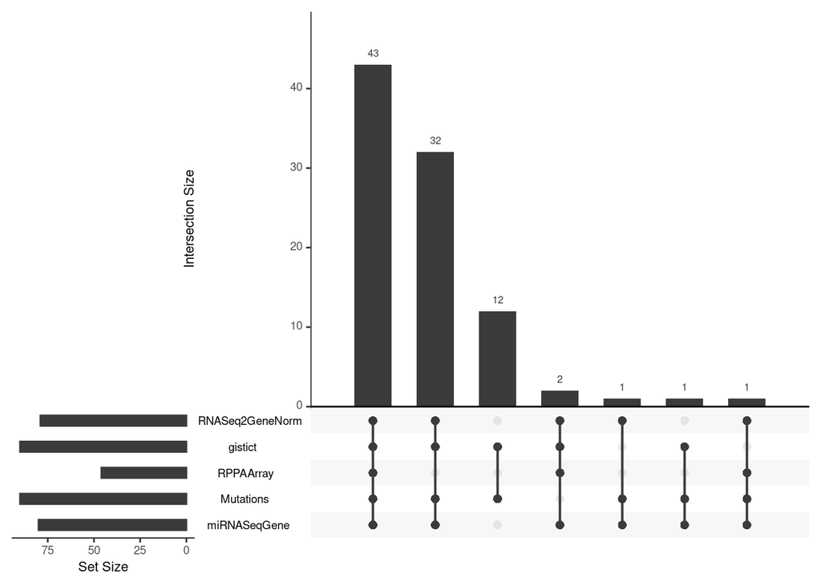

```r
data("miniACC")
upsetSamples(miniACC)
```

In this dataset only 43 samples have all 5 assays, 32 are missing reverse-phase protein (RPPAArray), 12 have only mutations and gistict, 2 are missing Mutations, 1 is missing gistict, etc.

## 2.2 Kaplan-meier plot stratified by pathology_N_stage

Create a Kaplan-meier plot, using pathology_N_stage as a stratifying variable.

**Solution**

The colData provides clinical data for things like a Kaplan-Meier plot for overall survival stratified by nodal stage.

```r
Surv(miniACC$days_to_death, miniACC$vital_status)
```

```
##  [1] 1355  1677    NA+  423   365    NA+  490   579    NA+  922   551  1750
## [13]   NA+ 2105    NA+  541    NA+   NA+  490    NA+   NA+  562    NA+   NA+
## [25]   NA+   NA+   NA+   NA+  289    NA+   NA+   NA+  552    NA+   NA+   NA+
## [37]  994    NA+   NA+  498    NA+   NA+  344    NA+   NA+   NA+   NA+   NA+
## [49]   NA+   NA+   NA+   NA+   NA+  391   125    NA+ 1852    NA+   NA+   NA+
## [61]   NA+   NA+   NA+   NA+ 1204   159  1197   662   445    NA+ 2385   436
## [73] 1105    NA+ 1613    NA+   NA+ 2405    NA+   NA+   NA+   NA+   NA+  207
## [85]    0    NA+   NA+   NA+   NA+   NA+   NA+  383
```

And remove any patients missing overall survival information:

```r
miniACCsurv <-
    miniACC[, complete.cases(miniACC$days_to_death, miniACC$vital_status), ]
miniACCsurv
```

```
## A MultiAssayExperiment object of 5 listed
##  experiments with user-defined names and respective classes.
##  Containing an ExperimentList class object of length 5:
##  [1] RNASeq2GeneNorm: SummarizedExperiment with 198 rows and 28 columns
##  [2] gistict: SummarizedExperiment with 198 rows and 33 columns
##  [3] RPPAArray: SummarizedExperiment with 33 rows and 14 columns
##  [4] Mutations: matrix with 97 rows and 33 columns
##  [5] miRNASeqGene: SummarizedExperiment with 471 rows and 29 columns
## Functionality:
##  experiments() - obtain the ExperimentList instance
##  colData() - the primary/phenotype DataFrame
##  sampleMap() - the sample coordination DataFrame
##  `$`, `[`, `[[` - extract colData columns, subset, or experiment
##  *Format() - convert into a long or wide DataFrame
##  assays() - convert ExperimentList to a SimpleList of matrices
##  exportClass() - save data to flat files
```

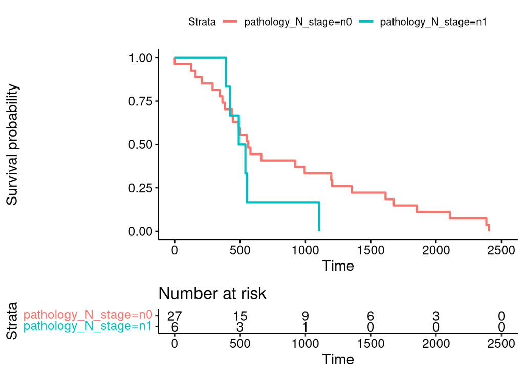

```r
fit <- survfit(
    Surv(days_to_death, vital_status) ~ pathology_N_stage,
    data = colData(miniACCsurv)
)
ggsurvplot(fit, data = colData(miniACCsurv), risk.table = TRUE)
```

## 2.3 Multivariate Cox regression including RNA-seq, copy number, and pathology

Choose the *EZH2* gene for demonstration. This subsetting will drop assays with no row named EZH2:

```r
wideacc = wideFormat(miniACC["EZH2", , ],
    colDataCols=c("vital_status", "days_to_death", "pathology_N_stage"))
```

```
## harmonizing input:
##   removing 216 sampleMap rows not in names(experiments)
```

```r
wideacc$y = Surv(wideacc$days_to_death, wideacc$vital_status)
head(wideacc)
```

```
## DataFrame with 6 rows and 7 columns
##        primary vital_status days_to_death pathology_N_stage
##    <character>    <integer>     <integer>       <character>
## 1 TCGA-OR-A5J1            1          1355                n0
## 2 TCGA-OR-A5J2            1          1677                n0
## 3 TCGA-OR-A5J3            0            NA                n0
## 4 TCGA-OR-A5J4            1           423                n1
## 5 TCGA-OR-A5J5            1           365                n0
## 6 TCGA-OR-A5J6            0            NA                n0
##   RNASeq2GeneNorm_EZH2 gistict_EZH2      y
##              <numeric>    <numeric> <Surv>
## 1              75.8886            0 1355:1
## 2             326.5332            1 1677:1
## 3             190.1940            1   NA:0
## 4                   NA           -2  423:1
## 5             366.3826            1  365:1
## 6              30.7371            1   NA:0
```

Perform a multivariate Cox regression with *EZH2* copy number (gistict), log2-transformed *EZH2* expression (RNASeq2GeneNorm), and nodal status (pathology_N_stage) as predictors:

```r
coxph(
    Surv(days_to_death, vital_status) ~
        gistict_EZH2 + log2(RNASeq2GeneNorm_EZH2) + pathology_N_stage,
    data=wideacc
)
```

```
## Call:
## coxph(formula = Surv(days_to_death, vital_status) ~ gistict_EZH2 +
##     log2(RNASeq2GeneNorm_EZH2) + pathology_N_stage, data = wideacc)
##
##                                coef exp(coef) se(coef)      z        p
## gistict_EZH2               -0.03723   0.96345  0.28205 -0.132 0.894986
## log2(RNASeq2GeneNorm_EZH2)  0.97731   2.65729  0.28105  3.477 0.000506
## pathology_N_stagen1         0.37749   1.45862  0.56992  0.662 0.507743
##
## Likelihood ratio test=16.28  on 3 df, p=0.0009942
## n= 26, number of events= 26
##    (66 observations deleted due to missingness)
```

We see that *EZH2* expression is significantly associated with overal survival (p < 0.001), but *EZH2* copy number and nodal status are not. This analysis could easily be extended to the whole genome for discovery of prognostic features by repeated univariate regressions over columns, penalized multivariate regression, etc.

For further detail, see the main `MultiAssayExperiment` vignette.

## 2.4 Correlation between RNA-seq and copy number

**Part 1**

For all genes where there is both recurrent copy number (gistict assay) and RNA-seq, calculate the correlation between log2(RNAseq + 1) and copy number. Create a histogram of these correlations. Compare this with the histogram of correlations between all *unmatched* gene - copy number pairs.

**Solution**

First, narrow down `miniACC` to only the assays needed:

```r
subacc <- miniACC[, , c("RNASeq2GeneNorm", "gistict")]
```

```
## harmonizing input:
##   removing 216 sampleMap rows not in names(experiments)
```

Align the rows and columns, keeping only samples with both assays available:

```r
subacc <- intersectColumns(subacc)
subacc <- intersectRows(subacc)
```

Create a list of numeric matrices:

```r
subacc.list <- assays(subacc)
```

Log-transform the RNA-seq assay:

```r
subacc.list[[1]] <- log2(subacc.list[[1]] + 1)
```

Transpose both, so genes are in columns:

```r
subacc.list <- lapply(subacc.list, t)
```

Calculate the correlation between columns in the first matrix and columns in the second matrix:

```r
corres <- cor(subacc.list[[1]], subacc.list[[2]])
```

And finally, create the histograms:

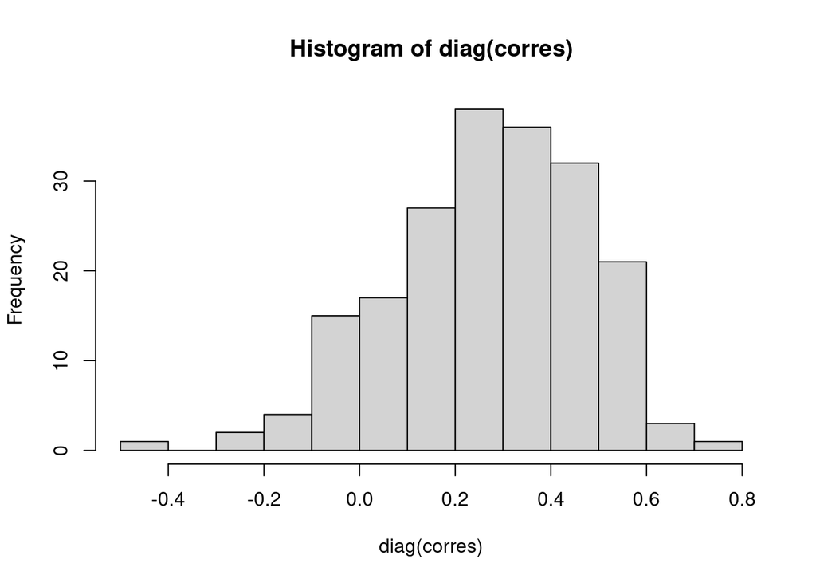

```r
hist(diag(corres))
```

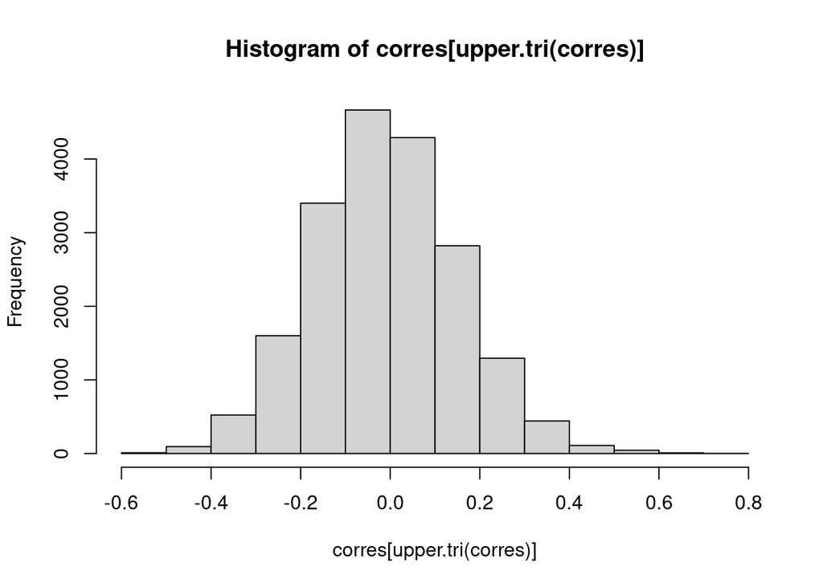

```r
hist(corres[upper.tri(corres)])
```

**Part 2**

**Solution**

First, identify the gene with highest correlation between expression and copy number:

```r
which.max(diag(corres))
```

```
## EIF4E
##    91
```

You could now make the plot by taking the EIF4E columns from each element of the list subacc.list *list* that was extracted from the subacc *MultiAssayExperiment*, but let’s do it by subsetting and extracting from the *MultiAssayExperiment*:

```r
df <- wideFormat(subacc["EIF4E", , ])
head(df)
```

```
## DataFrame with 6 rows and 3 columns
##        primary RNASeq2GeneNorm_EIF4E gistict_EIF4E
##    <character>             <numeric>     <numeric>
## 1 TCGA-OR-A5J1               460.615             0
## 2 TCGA-OR-A5J2               371.225             0
## 3 TCGA-OR-A5J3               516.072             0
## 4 TCGA-OR-A5J5              1129.357             1
## 5 TCGA-OR-A5J6               822.078             0
## 6 TCGA-OR-A5J7               344.565            -1
```

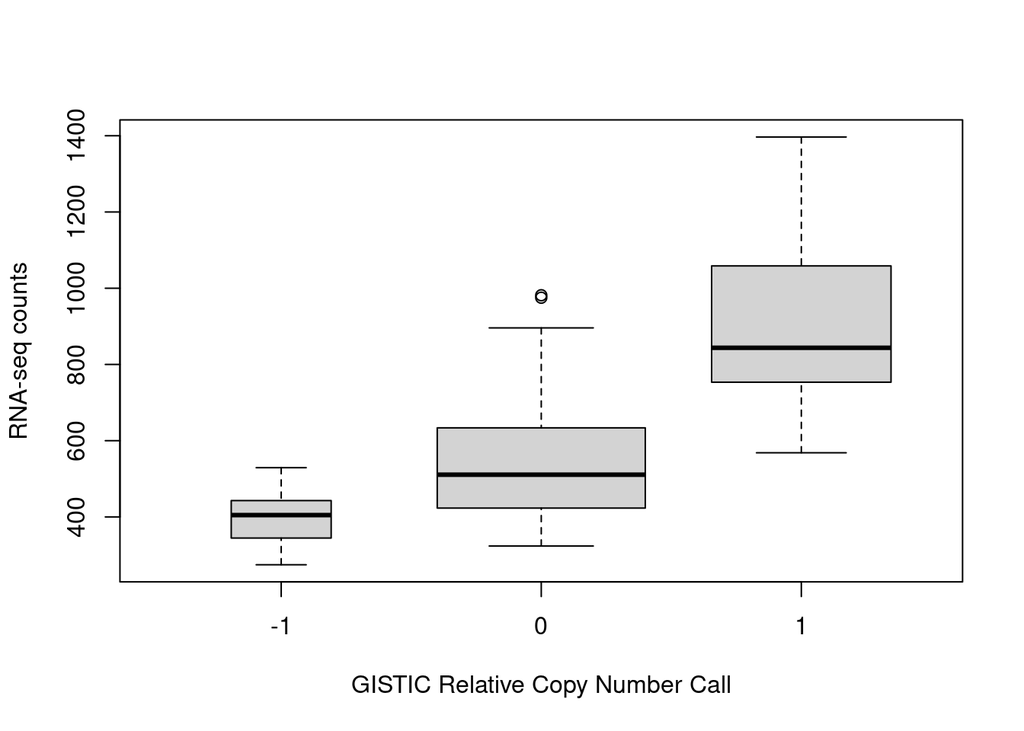

```r
boxplot(RNASeq2GeneNorm_EIF4E ~ gistict_EIF4E,
        data=df, varwidth=TRUE,
        xlab="GISTIC Relative Copy Number Call",
        ylab="RNA-seq counts")
```

## 2.5 Identifying correlated principal components

Perform Principal Components Analysis of each of the five assays, using samples available on each assay, log-transforming RNA-seq data first. Using the first 10 components, calculate Pearson correlation between all scores and plot these correlations as a heatmap to identify correlated components across assays.

**Solution**

Here’s a function to simplify doing the PCAs:

```r
getLoadings <-
    function(x, ncomp=10, dolog=FALSE, center=TRUE, scale.=TRUE) {
        if (dolog)
            x <- log2(x + 1)
        pc <- prcomp(x, center=center, scale.=scale.)
        t(pc$rotation[, 1:10])
    }
```

Although it would be possible to do the following with a loop, the different data types do require different options for PCA (e.g. mutations are a 0/1 matrix with 1 meaning there is a somatic mutation, and gistict varies between -2 for homozygous loss and 2 for a genome doubling, so neither make sense to scale and center). So it is just as well to do the following one by one, concatenating each PCA results to the MultiAssayExperiment:

```r
miniACC2 <- intersectColumns(miniACC)
miniACC2 <- c(miniACC2,
    rnaseqPCA = getLoadings(assays(miniACC2)[[1]], dolog=TRUE),
    gistictPCA = getLoadings(
        assays(miniACC2)[[2]], center=FALSE, scale.=FALSE
    ),
    proteinPCA = getLoadings(assays(miniACC2)[[3]]),
    mutationsPCA = getLoadings(
        assays(miniACC2)[[4]], center=FALSE, scale.=FALSE
    ),
    miRNAPCA = getLoadings(assays(miniACC2)[[5]]),
    mapFrom = 1:5
)
```

Now subset to keep *only* the PCA results:

```r
miniACC2 <- miniACC2[, , grep("PCA$", names(miniACC2))]
```

```
## harmonizing input:
##   removing 215 sampleMap rows not in names(experiments)
```

```r
experiments(miniACC2)
```

```
## ExperimentList class object of length 5:
##  [1] rnaseqPCA: matrix with 10 rows and 43 columns
##  [2] gistictPCA: matrix with 10 rows and 43 columns
##  [3] proteinPCA: matrix with 10 rows and 43 columns
##  [4] mutationsPCA: matrix with 10 rows and 43 columns
##  [5] miRNAPCA: matrix with 10 rows and 43 columns
```

Note, it would be equally easy (and maybe better) to do PCA on all samples available for each assay, then do intersectColumns at this point instead.

Now, steps for calculating the correlations and plotting a heatmap:

- Use *wideFormat* to paste these together, which has the nice property of adding assay names to the column names.
- The first column always contains the sample identifier, so remove it.
- Coerce to a matrix
- Calculate the correlations, and take the absolute value (since signs of principal components are arbitrary)
- Set the diagonals to NA (each variable has a correlation of 1 to itself).

```r
df <- wideFormat(miniACC2)[, -1]
mycors <- cor(as.matrix(df))
mycors <- abs(mycors)
diag(mycors) <- NA
```

To simplify the heatmap, show only components that have at least one correlation greater than 0.5.

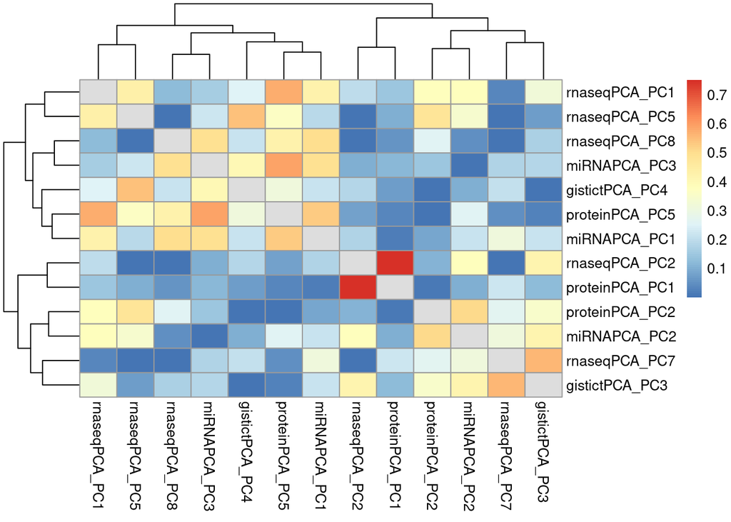

```r
has.high.cor <- apply(mycors, 2, max, na.rm=TRUE) > 0.5
mycors <- mycors[has.high.cor, has.high.cor]
pheatmap(mycors)
```

The highest correlation present is between PC2 of the RNA-seq assay, and PC1 of the protein assay.

# References

Ramos, Marcel, Ludwig Geistlinger, Sehyun Oh, Lucas Schiffer, Rimsha Azhar, Hanish Kodali, Ino de Bruijn, et al. 2020. “Multiomic Integration of Public Oncology Databases in Bioconductor.” *JCO Clin Cancer Inform* 4 (October): 958–71.

Ramos, Marcel, Lucas Schiffer, Angela Re, Rimsha Azhar, Azfar Basunia, Carmen Rodriguez, Tiffany Chan, et al. 2017. “Software for the Integration of Multiomics Experiments in Bioconductor.” *Cancer Res.* 77 (21): e39–42.